# Mi primer reporte de calidad de datos

Práctica introductoria a Quarto · Curso INEC

Autor/a

Participante del curso

Fecha de publicación

11 de noviembre de 2026

## 1 Introducción

Este informe presenta una **exploración descriptiva inicial** de un conjunto de **datos sintéticos** de personas y hogares. No contiene información oficial del INEC. Su finalidad es aprender a escribir un documento reproducible en Quarto.

## 2 Objetivos

- Leer un CSV sin cambiar automáticamente los identificadores.
- Calcular indicadores sencillos de calidad de datos.
- Presentar una tabla y un gráfico creados desde R.
- Interpretar los resultados y reconocer sus limitaciones.

## 3 Metodología

Se utiliza `data_raw/personas_encuesta_sintetica_2026_10.csv`. El archivo se lee como texto para conservar códigos y para separar la importación de la conversión de variables numéricas. Las cifras del informe se calculan al generar el reporte.

### 3.1 Preparación y lectura

```r
# Cargar bibliotecas una vez al inicio del informe.
library(readr)
library(dplyr)
library(ggplot2)
library(knitr)
library(here)

ruta_csv <- here::here("data_raw", "personas_encuesta_sintetica_2026_10.csv")

# La ruta es relativa a la carpeta donde se guarda este .qmd.
#ruta_csv <- "data_raw/personas_encuesta_sintetica_2026_10.csv"

# Detener la ejecución con un mensaje claro si falta el archivo.
if (!file.exists(ruta_csv)) {
  stop("No se encuentra el CSV. Revise la carpeta data_raw/.")
}

# Leer las 27 columnas como texto: no se pierden ceros iniciales en los IDs.
datos <- read_csv(
  ruta_csv,
  col_types = cols(.default = col_character()),
  na = "NA",
  trim_ws = FALSE,
  show_col_types = FALSE
)

# Crear una COPIA de trabajo con dos columnas numéricas nuevas.
# suppressWarnings evita mensajes por textos que no pueden convertirse;
# esas conversiones quedan como NA y deben analizarse posteriormente.
datos_trabajo <- datos %>%
  mutate(
    edad_n = suppressWarnings(as.numeric(trimws(edad))),
    ingreso_n = suppressWarnings(as.numeric(trimws(ingreso_mensual_usd)))
  )
```

## 4 Resultados

### 4.1 1. Resumen general del archivo

El conjunto contiene **1500 registros** y **27 variables originales**. Los dos campos numéricos derivados (`edad_n` e `ingreso_n`) solo existen en `datos_trabajo` y no modifican el CSV.

```r
# Crear indicadores sencillos. La columna 'Valor' es numérica.
resumen <- tibble::tibble(
  Indicador = c("Registros", "Variables originales", "Edad ausente o no interpretable",
                "Ingresos iguales a cero"),
  Valor = c(
    nrow(datos),
    ncol(datos),
    sum(is.na(datos_trabajo$edad_n)),
    sum(datos_trabajo$ingreso_n == 0, na.rm = TRUE)
  )
)

# Convertir la tabla en una presentación apta para HTML y Word.
knitr::kable(resumen, caption = "Indicadores descriptivos del CSV")
```

Indicadores descriptivos del CSV

| Indicador | Valor |
| --- | --- |
| Registros | 1500 |
| Variables originales | 27 |
| Edad ausente o no interpretable | 72 |
| Ingresos iguales a cero | 928 |

**Interpretación:** una edad que no puede convertirse a número se contabiliza aquí junto con las ausencias; para distinguir los motivos se necesitaría una revisión más específica, como la realizada en el módulo 3.

### 4.2 2. Tabla de frecuencias de condición de actividad

```r
# Contar personas por categoría y calcular el porcentaje del total.
tabla_actividad <- datos_trabajo %>%
  count(condicion_actividad, name = "registros", sort = TRUE) %>%
  mutate(porcentaje = round(100 * registros / sum(registros), 1))

knitr::kable(tabla_actividad, caption = "Frecuencia de condición de actividad")
```

Frecuencia de condición de actividad

| condicion_actividad | registros | porcentaje |
| --- | --- | --- |
| Ocupado | 530 | 35.3 |
| Desocupado | 492 | 32.8 |
| Inactivo | 478 | 31.9 |

### 4.3 3. Gráfico de frecuencias

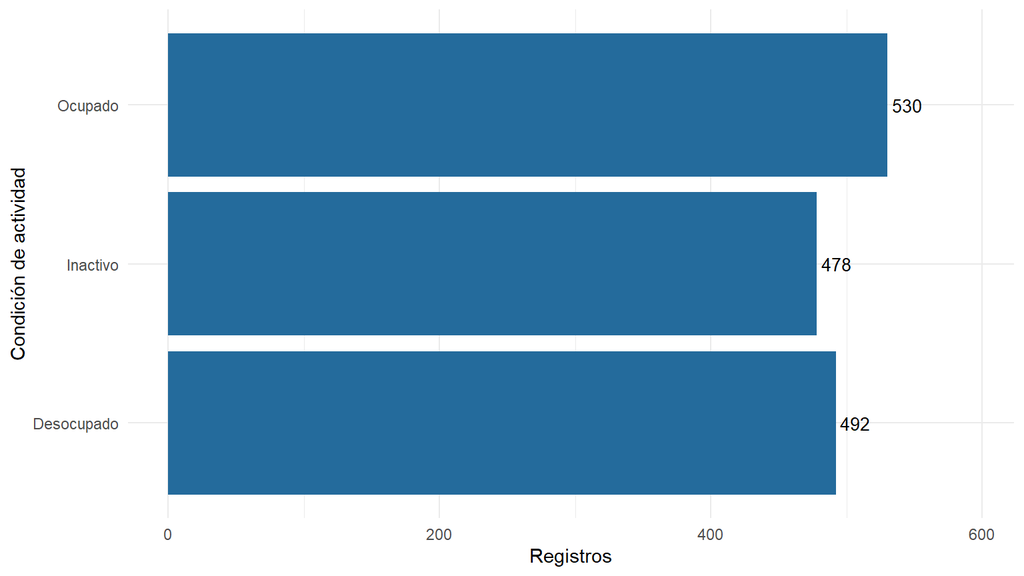

Número de registros por condición de actividad

```r
# geom_col() dibuja las barras usando los conteos ya calculados.
ggplot(tabla_actividad,
       aes(x = condicion_actividad, y = registros)) +
  geom_col(fill = "#246B9C") +
  geom_text(aes(label = registros), hjust = -0.15, size = 3.5) +
  coord_flip() +
  labs(x = "Condición de actividad", y = "Registros") +
  expand_limits(y = max(tabla_actividad$registros) * 1.12) +
  theme_minimal()
```

### 4.4 4. Media y mediana de ingreso mensual

Para el ejercicio se usan solo ingresos numéricos **no negativos**. Un cero puede ser un valor válido; no equivale a un dato ausente. Un valor muy alto puede afectar la media, pero no necesariamente invalida el dato.

```r
# Seleccionar ingresos informados y no negativos sin tocar el origen.
ingresos_validos <- datos_trabajo$ingreso_n[
  !is.na(datos_trabajo$ingreso_n) & datos_trabajo$ingreso_n >= 0
]

if (length(ingresos_validos) == 0) {
  stop("No existen ingresos numéricos no negativos para el resumen")
}

estadisticos_ingreso <- tibble::tibble(
  Estadistico = c("Media", "Mediana"),
  USD = round(c(mean(ingresos_validos), median(ingresos_validos)), 2)
)
knitr::kable(estadisticos_ingreso,
             caption = "Resumen descriptivo de ingreso mensual (USD)")
```

Resumen descriptivo de ingreso mensual (USD)

| Estadistico | USD |
| --- | --- |
| Media | 1017.45 |
| Mediana | 0.00 |

## 5 Interpretación y discusión

La tabla y el gráfico permiten comparar la frecuencia de las condiciones de actividad. La media y la mediana del ingreso pueden ser distintas porque responden de manera diferente a los valores extremos y a la presencia de ceros.

## 6 Conclusiones

1. Quarto permite reunir texto, cálculos, tablas y gráficos en un mismo documento.
2. Los resultados cambian automáticamente cuando se vuelve a generar el informe utilizando otro CSV compatible.
3. Un reporte descriptivo no sustituye los controles de validación, consistencia y aprobación de los módulos 4, 5 y 6.

## 7 Limitaciones y recomendaciones

- Los datos son sintéticos, con anomalías introducidas para la capacitación.
- La conversión de texto a número puede producir `NA`; requiere diagnóstico.
- No se realizaron correcciones ni imputaciones en el archivo original.
- Antes de usar un reporte institucional se deben verificar reglas y metodología.

## 8 Referencias

- Quarto. [Tutorial introductorio en RStudio](https://quarto.org/docs/get-started/hello/rstudio.html).
- Quarto. [Trabajo con R](https://quarto.org/docs/computations/r.html).
- Curso INEC (material didáctico, noviembre de 2026): *Evaluación de archivos de datos y automatización de reportes de calidad en R*.